# NHANES Meal Archetypes

August 2021-August 2023 WWEIA / NHANES first-pass meal taxonomy

## 1 NHANES provides a practical starting point for a U.S. meal universe

This report uses public NHANES / WWEIA food-intake files for August 2021 through August 2023 to build a first-pass meal taxonomy from Day 1 dietary recall data. It establishes an evidence-based view of what Americans actually eat, then compares how those meal patterns vary by income.

That makes the output useful as a screening tool for later mapping into NiQ supercategories. In practical terms, the analysis answers a narrower but decision-relevant question: which meal archetypes are common enough, and stable enough across income groups, to anchor a grocery basket strategy.

The analysis draws on four public NHANES/WWEIA files: demographics, Day 1 individual foods, food-code descriptions, and USDA food-category mapping.

Meals are collapsed into meal events and then assigned archetypes using a transparent rules-based heuristic. The unit of analysis is one respondent, one day, one eating occasion; meals are weighted with `WTDRD1` and stratified by income-to-poverty ratio. Source-file details, derivation steps, and design rationale are in the Appendix.

## 2 The underlying sample is large enough for directional SES comparisons

The four source files yield 88,006 food rows across 6,679 respondents, which collapse into 28,890 meal events (mean 425 kcal per meal). Detailed file-level row counts and calorie distributions are in the Appendix.

### 2.1 Income strata are large enough for directional reads

This table shows the sample sizes for the income groups used later in the report. It is mainly a coverage check: before interpreting high-SES or low-SES meal patterns, it is useful to know how many respondents are contributing to each slice and whether the age mix differs materially across them.

| group | participants | mean_age |
| --- | --- | --- |
| All Respondents | 6679 | 42.3 |
| Higher SES (PIR >= 3) | 2691 | 45.9 |
| Highest SES (PIR >= 5) | 1436 | 46.1 |
| Lower SES (PIR < 1.3) | 1432 | 35.4 |

### 2.2 Snacks and dinners account for most weighted meal volume

The plot below shows the overall meal mix before any archetype labeling. Snacks account for the largest share of weighted meal events; dinners are second. A detailed occasion-level table is in the Appendix.

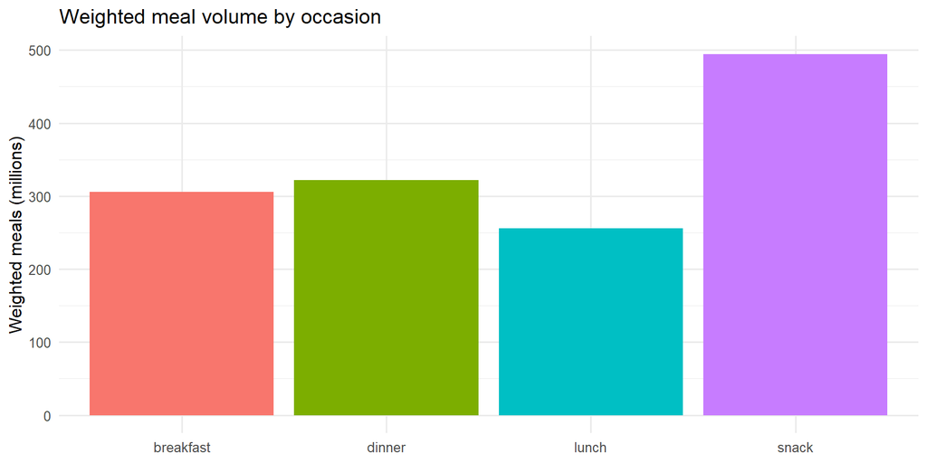

## 3 A simple rules-based taxonomy captures the major meal families

Meals are grouped into broad archetypes using two signals:

- food-group presence, inferred from USDA food-category descriptions
- USDA combination codes, which flag cases such as sandwiches, salads, cereal combinations, soups, and tortilla-based combinations

### 3.1 A worked example shows how item-level foods become a meal archetype

The example below traces one eating occasion from individual reported foods to the final meal label. This is the central analytical move in the document: multiple food rows are grouped into one meal event, broad food groups are inferred from USDA descriptions, and then the meal is assigned an archetype using a transparent sequence of rules.

Item-level foods that make up one example meal

| SEQN | time_code | occasion | food_category | food_group | kcal |
| --- | --- | --- | --- | --- | --- |
| 130379 | 43200 | lunch | Burgers | sandwich | 330 |
| 130379 | 43200 | lunch | Mustard and other condiments | condiment_fat | 7 |
| 130379 | 43200 | lunch | Corn | vegetables | 95 |
| 130379 | 43200 | lunch | Coleslaw, non-lettuce salads | vegetables | 54 |
| 130379 | 43200 | lunch | Candy containing chocolate | sweet_baked | 44 |

The corresponding derived meal row

| meal_key | SEQN | occasion | total_kcal | pir | top_groups | top_categories | archetype |
| --- | --- | --- | --- | --- | --- | --- | --- |
| 130379\|43200\|lunch | 130379 | lunch | 530 | 5 | sandwich, vegetables, sweet_baked, condiment_fat | Burgers, Corn, Coleslaw, non-lettuce salads, Candy containing chocolate, Mustard and other condiments | sandwich lunch |

In this example, the raw food items are first translated into broader meal components such as `sandwich`, `water`, or `sweet_drink`. Those components are then evaluated in a simple hierarchy of rules. Because the eating occasion is lunch and the grouped foods clearly signal a sandwich format, the meal is classified as `sandwich lunch`.

That same logic is applied across the full meal file. The resulting archetypes are therefore best understood as standardized summaries of reported eating occasions rather than ad hoc labels assigned case by case.

```r
build_label <- function(occasion, groups, combos) {
  groups <- unlist(groups)
  combos <- unlist(combos)

  if (occasion == "breakfast") {
    if ("cereal_combo" %in% combos || "cereal_oatmeal" %in% groups) return("cereal or oatmeal breakfast")
    if ("sandwich_combo" %in% combos || "sandwich" %in% groups || ("tortilla_combo" %in% combos && any(c("eggs", "meat_poultry") %in% groups))) return("breakfast sandwich or burrito")
    if ("eggs" %in% groups && any(c("bread", "breakfast_meat") %in% groups)) return("eggs with bread or meat")
    if ("coffee_tea" %in% groups && any(c("sweet_baked", "bread") %in% groups)) return("coffee and pastry breakfast")
    if (all(c("yogurt", "fruit") %in% groups)) return("yogurt and fruit breakfast")
    if (all(c("fruit", "bread") %in% groups)) return("fruit and bread breakfast")
    if ("coffee_tea" %in% groups) return("coffee-first breakfast")
    return("other breakfast")
  }

  if (occasion == "lunch") {
    if ("sandwich_combo" %in% combos || "sandwich" %in% groups) return("sandwich lunch")
    if ("salad_combo" %in% combos || "salad" %in% groups) return("salad lunch")
    if ("soup_combo" %in% combos || "soup" %in% groups) return("soup lunch")
    if ("tortilla_combo" %in% combos || "tortilla" %in% groups) return("tortilla lunch")
    if ("pizza" %in% groups) return("pizza lunch")
    if (length(intersect(c("meat_poultry", "seafood"), groups)) > 0 && length(intersect(c("grain_starch", "vegetables"), groups)) > 0) return("plate lunch")
    if ("mixed_main" %in% groups || "mixed_combo" %in% combos) return("mixed entree lunch")
    return("other lunch")
  }

  if (occasion == "dinner") {
    if ("tortilla_combo" %in% combos || "tortilla" %in% groups) return("tortilla dinner")
    if ("pizza" %in% groups) return("pizza dinner")
    if ("soup_combo" %in% combos || "soup" %in% groups) return("soup dinner")
    if (length(intersect(c("meat_poultry", "seafood", "beans_nuts"), groups)) > 0 && all(c("grain_starch", "vegetables") %in% groups)) return("protein vegetable starch dinner")
    if (length(intersect(c("meat_poultry", "seafood", "beans_nuts"), groups)) > 0 && "grain_starch" %in% groups) return("protein and starch dinner")
    if ("mixed_main" %in% groups || any(c("mixed_combo", "frozen_meal_combo") %in% combos)) return("mixed entree dinner")
    if ("sandwich_combo" %in% combos || "sandwich" %in% groups) return("sandwich dinner")
    return("other dinner")
  }

  if (occasion == "snack") {
    if ("chips_combo" %in% combos || "salty_snack" %in% groups) return("salty snack")
    if ("sweet_baked" %in% groups) return("sweet snack")
    if ("fruit" %in% groups && any(c("yogurt", "cheese") %in% groups)) return("fruit and dairy snack")
    if ("sandwich_combo" %in% combos || "sandwich" %in% groups) return("sandwich snack")
    if ("coffee_tea" %in% groups) return("coffee or tea snack")
    return("other snack")
  }

  "other occasion"
}
```

## 4 The leading archetypes are intuitive enough to inform category selection

```r
top_archetypes <- function(summary_df, stratum_name, occasion_name, n = 5) {
  summary_df %>%
    filter(stratum == stratum_name, occasion == occasion_name) %>%
    slice_head(n = n) %>%
    transmute(
      archetype,
      weighted_share = scales::percent(weighted_share, accuracy = 0.1),
      participants,
      typical_groups = vapply(top_groups, compact_list, character(1), limit = 4),
      typical_foods = vapply(top_categories, compact_list, character(1), limit = 4)
    )
}
```

### 4.1 The mainstream meal set is anchored by a small number of repeatable patterns

#### 4.1.1 Breakfast splits across cereal, coffee-led, and convenience formats

| archetype | weighted_share | participants | typical_groups | typical_foods |
| --- | --- | --- | --- | --- |
| other breakfast | 30.7% | 1790 | sweet_baked, sweet_drink, water, fruit | Doughnuts, sweet rolls, pastries, Eggs and omelets |
| cereal or oatmeal breakfast | 21.6% | 1469 | cereal_oatmeal, milk_dairy_drink, water, coffee_tea | Ready-to-eat cereal, higher sugar (>21.2g/100g), Milk, whole |
| coffee-first breakfast | 15.8% | 991 | condiment_fat, coffee_tea, milk_dairy_drink, water | Coffee, Cream and cream substitutes, Sugars and honey |
| coffee and pastry breakfast | 9.8% | 639 | bread, condiment_fat, coffee_tea, sweet_baked | Doughnuts, sweet rolls, pastries, Coffee |
| breakfast sandwich or burrito | 9.6% | 561 | sandwich, condiment_fat, coffee_tea, water | Egg/breakfast sandwiches, Coffee, Tap water, Deli and cured meat sandwiches |

#### 4.1.2 Lunch remains sandwich-led, with salads and plate meals forming the next tier

| archetype | weighted_share | participants | typical_groups | typical_foods |
| --- | --- | --- | --- | --- |
| other lunch | 28.4% | 1508 | sweet_drink, water, grain_starch, fruit | Bottled water, Pasta mixed dishes, excludes macaroni and cheese, Tap water |
| sandwich lunch | 28.3% | 1506 | sandwich, condiment_fat, vegetables, water | Deli and cured meat sandwiches, Mayonnaise, Peanut butter and jelly sandwiches, Cheese sandwiches |
| plate lunch | 10.9% | 573 | meat_poultry, grain_starch, vegetables | Chicken patties, nuggets and tenders, French fries and other fried white potatoes, Tomato-based condiments |
| mixed entree lunch | 10.5% | 525 | mixed_main, water, sweet_drink, condiment_fat | Meat mixed dishes, Poultry mixed dishes, Tap water, Fried rice and lo/chow mein |
| salad lunch | 7.1% | 376 | condiment_fat, vegetables, meat_poultry, cheese | Chicken, whole pieces, Cheese, Salad dressings and vegetable oils |

#### 4.1.3 Dinner is more fragmented, with sandwiches, tortillas, and mixed entrees all material

| archetype | weighted_share | participants | typical_groups | typical_foods |
| --- | --- | --- | --- | --- |
| other dinner | 30.4% | 2027 | grain_starch, sweet_baked, water | Pasta mixed dishes, excludes macaroni and cheese, Chicken, whole pieces |
| mixed entree dinner | 16.4% | 1028 | mixed_main, water, sweet_drink, grain_starch | Meat mixed dishes, Poultry mixed dishes, Pasta mixed dishes, excludes macaroni and cheese |
| sandwich dinner | 15.0% | 930 | sandwich, condiment_fat, vegetables, sweet_drink | Burgers, French fries and other fried white potatoes, Soft drinks, Deli and cured meat sandwiches |
| protein vegetable starch dinner | 9.4% | 637 | meat_poultry, grain_starch, vegetables, water | Beef, excludes ground, Milk, whole |
| protein and starch dinner | 8.6% | 577 | grain_starch, meat_poultry, water | Pork, Rice, Mashed potatoes and white potato mixtures, Chicken |

#### 4.1.4 Snacks are concentrated in sweet, salty, and residual grab-and-go occasions

| archetype | weighted_share | participants | typical_groups | typical_foods |
| --- | --- | --- | --- | --- |
| other snack | 37.0% | 2811 | fruit, water, beans_nuts, sweet_drink | Nuts and seeds, Apples, Bananas, Citrus fruits |
| sweet snack | 35.8% | 2920 | sweet_baked, water, sweet_drink, milk_dairy_drink | Candy not containing chocolate, Cookies and brownies, Candy containing chocolate, Ice cream and frozen dairy desserts |
| salty snack | 22.0% | 1989 | salty_snack, water, sweet_drink, sweet_baked | Tortilla, corn, other chips, Popcorn |
| coffee or tea snack | 3.0% | 295 | coffee_tea, condiment_fat, beans_nuts, bread | Tea, Coffee, Cream and cream substitutes, Nuts and seeds |
| sandwich snack | 1.4% | 137 | sandwich, condiment_fat, water, sweet_drink | Peanut butter and jelly sandwiches, Deli and cured meat sandwiches, Mayonnaise, Cheese sandwiches |

### 4.2 Higher-income households skew toward coffee-led breakfasts and more composed lunches

The next tables focus on the income slices most relevant for the less-budget-constrained meal universe question. Their value is in identifying which meal formats become more prominent when budget pressure is likely to be lower.

#### 4.2.1 High-income breakfasts skew more heavily toward coffee and cereal

| archetype | weighted_share | participants | typical_groups | typical_foods |
| --- | --- | --- | --- | --- |
| other breakfast | 26.0% | 353 | sweet_drink, sweet_baked, fruit, water | Tap water, Eggs and omelets, Smoothies and grain drinks, Nutritional beverages |
| cereal or oatmeal breakfast | 23.7% | 364 | cereal_oatmeal, milk_dairy_drink, coffee_tea, condiment_fat | Ready-to-eat cereal, higher sugar (>21.2g/100g), Milk, reduced fat |
| coffee-first breakfast | 18.0% | 266 | condiment_fat, coffee_tea, milk_dairy_drink, eggs | Coffee, Cream and cream substitutes, Sugars and honey, Sugar substitutes |
| coffee and pastry breakfast | 10.5% | 160 | bread, condiment_fat, coffee_tea, sweet_baked | Biscuits, muffins, quick breads, Coffee |
| eggs with bread or meat | 10.2% | 140 | bread, eggs, condiment_fat, coffee_tea | Eggs and omelets, Yeast breads, Pancakes, waffles |

#### 4.2.2 High-income lunches still center on sandwiches but shift up toward salads and mixed entrees

| archetype | weighted_share | participants | typical_groups | typical_foods |
| --- | --- | --- | --- | --- |
| sandwich lunch | 29.3% | 359 | sandwich, condiment_fat, vegetables, salty_snack | Peanut butter and jelly sandwiches, Deli and cured meat sandwiches, Mayonnaise, Cheese sandwiches |
| other lunch | 26.9% | 341 | sweet_drink, grain_starch, sweet_baked, fruit | Pasta mixed dishes, excludes macaroni and cheese, Smoothies and grain drinks, Nutritional beverages |
| mixed entree lunch | 12.1% | 139 | mixed_main, condiment_fat, grain_starch, sweet_drink | Meat mixed dishes, Pasta mixed dishes, excludes macaroni and cheese, Cheese |
| salad lunch | 9.5% | 131 | condiment_fat, meat_poultry, cheese, vegetables | Salad dressings and vegetable oils, Chicken, whole pieces, Cheese |
| plate lunch | 8.7% | 103 | grain_starch, meat_poultry, sweet_drink, vegetables | Apples, Crackers, excludes saltines, Dips |

#### 4.2.3 High-income dinners diversify away from tortilla formats and toward mixed entrees

| archetype | weighted_share | participants | typical_groups | typical_foods |
| --- | --- | --- | --- | --- |
| other dinner | 28.7% | 421 | grain_starch, sweet_baked, alcohol, water | Pasta mixed dishes, excludes macaroni and cheese, Cakes and pies, Cookies and brownies |
| mixed entree dinner | 21.4% | 280 | mixed_main, water, grain_starch, cheese | Meat mixed dishes, Pasta mixed dishes, excludes macaroni and cheese, Cheese |
| sandwich dinner | 12.8% | 167 | sandwich, condiment_fat, vegetables, grain_starch | Egg/breakfast sandwiches, Deli and cured meat sandwiches, Mayonnaise, Tap water |
| protein vegetable starch dinner | 11.5% | 183 | grain_starch, meat_poultry, vegetables, water | Chicken, whole pieces, Cheese, Rice |
| protein and starch dinner | 7.3% | 102 | grain_starch, meat_poultry, water, beans_nuts | Beans, peas, legumes, Rice mixed dishes |

#### 4.2.4 High-income snacks look broadly similar, with a modest tilt toward coffee occasions

| archetype | weighted_share | participants | typical_groups | typical_foods |
| --- | --- | --- | --- | --- |
| other snack | 36.8% | 629 | fruit, beans_nuts, water, sweet_drink | Nuts and seeds, Apples, Bananas, Citrus fruits |
| sweet snack | 34.9% | 640 | sweet_baked, water, coffee_tea, fruit | Cookies and brownies, Candy containing chocolate, Candy not containing chocolate, Ice cream and frozen dairy desserts |
| salty snack | 22.4% | 450 | salty_snack, water, sweet_drink, sweet_baked | Crackers, excludes saltines, Tortilla, corn |
| coffee or tea snack | 4.0% | 84 | coffee_tea, condiment_fat, beans_nuts, fruit | Coffee, Tea, Nuts and seeds, Cream and cream substitutes |
| fruit and dairy snack | 1.1% | 26 | cheese, fruit, yogurt, water | Cheese, Apples, Nuts and seeds, Milk |

### 4.3 The clearest SES differences appear in dinner format rather than in snacking behavior

| group | occasion | archetype | weighted_share | participants |
| --- | --- | --- | --- | --- |
| Highest SES (PIR >= 5) | breakfast | other breakfast | 26.0% | 353 |
| Highest SES (PIR >= 5) | breakfast | cereal or oatmeal breakfast | 23.7% | 364 |
| Highest SES (PIR >= 5) | breakfast | coffee-first breakfast | 18.0% | 266 |
| Highest SES (PIR >= 5) | dinner | other dinner | 28.7% | 421 |
| Highest SES (PIR >= 5) | dinner | mixed entree dinner | 21.4% | 280 |
| Highest SES (PIR >= 5) | dinner | sandwich dinner | 12.8% | 167 |
| Highest SES (PIR >= 5) | lunch | sandwich lunch | 29.3% | 359 |
| Highest SES (PIR >= 5) | lunch | other lunch | 26.9% | 341 |
| Highest SES (PIR >= 5) | lunch | mixed entree lunch | 12.1% | 139 |
| Highest SES (PIR >= 5) | snack | other snack | 36.8% | 629 |
| Highest SES (PIR >= 5) | snack | sweet snack | 34.9% | 640 |
| Highest SES (PIR >= 5) | snack | salty snack | 22.4% | 450 |
| Lower SES (PIR < 1.3) | breakfast | other breakfast | 32.8% | 392 |
| Lower SES (PIR < 1.3) | breakfast | cereal or oatmeal breakfast | 21.8% | 286 |
| Lower SES (PIR < 1.3) | breakfast | coffee-first breakfast | 13.2% | 164 |
| Lower SES (PIR < 1.3) | dinner | other dinner | 30.8% | 442 |
| Lower SES (PIR < 1.3) | dinner | mixed entree dinner | 13.5% | 179 |
| Lower SES (PIR < 1.3) | dinner | sandwich dinner | 13.4% | 194 |
| Lower SES (PIR < 1.3) | lunch | other lunch | 30.6% | 323 |
| Lower SES (PIR < 1.3) | lunch | sandwich lunch | 26.4% | 266 |
| Lower SES (PIR < 1.3) | lunch | plate lunch | 11.6% | 130 |
| Lower SES (PIR < 1.3) | snack | other snack | 39.8% | 593 |
| Lower SES (PIR < 1.3) | snack | sweet snack | 34.1% | 578 |
| Lower SES (PIR < 1.3) | snack | salty snack | 20.9% | 408 |

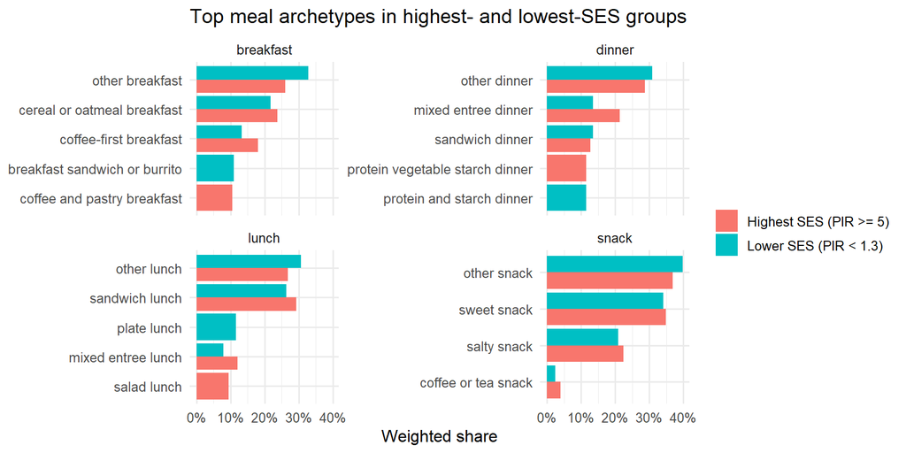

## 5 Five implications matter most for category selection

- Breakfast becomes more coffee-centered as SES rises.
- Lunch remains sandwich-heavy across strata, but salad lunches gain share in higher SES.
- Lower-SES dinners are more tortilla-centered than highest-SES dinners.
- Snacks are dominated by `other snack`, `sweet snack`, and `salty snack` in every income group.
- `Other` buckets remain large enough that a second-pass taxonomy refinement would be valuable before mapping directly into NiQ categories.

## 6 Mapping archetypes to NielsenIQ supercategories: a constrained 20-category recommendation

The disaggregated supercategory list for Food & Beverages (`Super Category - Food & Beverages (Disagg list).xlsx`) contains 54 supercategories. If we can request data from at most 20 of them, the selection below maximises the number of meal archetypes that can be identified — or reasonably approximated — from Homescan purchase data.

This is a coverage-maximising request list under the disagg-list-only constraint, not a claim that Homescan can reconstruct every meal archetype one-for-one.

One binding constraint shapes every choice that follows: **MEAT does not appear in the 54-item disagg list.** The `meat_poultry` food group is the defining ingredient in several high-prevalence dinner and lunch archetypes (protein + starch dinner, plate lunch, sandwich lunch/dinner). PREPARED FOODS, MEAL COMBOS, and SEAFOOD partially bridge the gap, but protein-centred archetypes will always have weaker coverage than they should.

**Practical takeaway:** most remaining tradeoffs in the 20-category list are downstream of the missing MEAT supercategory, not of the NHANES archetype logic.

### 6.1 The 20 picks

| # | NiQ Supercategory | NHANES Food Group(s) | Key Archetypes Served | Rationale |
| --- | --- | --- | --- | --- |
| 1 | CEREAL & GRANOLA | cereal_oatmeal | Cereal/oatmeal breakfast (21.6%) | Highly diagnostic — cereal purchase almost certainly means cereal breakfast |
| 2 | COFFEE | coffee_tea | Coffee-first breakfast (15.8%), coffee & pastry (9.8%), coffee/tea snack (3.0%) | Diagnostic of 3 archetypes totalling ~29% of breakfasts |
| 3 | BREAD | bread | Eggs w/ bread breakfast (9.5%), sandwich lunch/dinner/snack, coffee & pastry | Core ingredient in the most common lunch archetype (sandwich, 28.3%) |
| 4 | MILK PRODUCTS | milk_dairy_drink | Cereal breakfast (pairs w/ cereal) | Cereal + milk co-purchase is the strongest archetype signal in the data |
| 5 | EGGS | eggs | Eggs w/ bread/meat breakfast (9.5%), breakfast sandwich (9.6%) | Diagnostic of morning protein archetypes |
| 6 | SALTY SNACKS | salty_snack | Salty snack (22.0% of all snacks) | Near-perfect diagnostic match to a single high-prevalence archetype |
| 7 | COOKIES & CRACKERS | sweet_baked (partial), salty_snack (crackers) | Sweet snack (35.8%), salty snack overlap | Bridges both sweet and salty snack archetypes |
| 8 | DESSERTS/SWEET GOODS | sweet_baked (ice cream, cakes, pudding) | Sweet snack (35.8%) | Combined with COOKIES & CRACKERS, covers the single largest archetype by meal count |
| 9 | PREPARED FOODS | soup, mixed_main (partial) | Soup lunch (4.6%), soup dinner (5.9%), mixed entree meals | Covers soup archetypes + partially bridges the meat gap (rotisserie chicken, frozen meals) |
| 10 | MEAL COMBOS | mixed_main (partial) | Mixed entree dinner (16.4%), mixed entree lunch (10.5%) | Frozen meals, mac & cheese, skillet meals — diagnostic of the 2nd-largest dinner archetype |
| 11 | PASTA/RICE/GRAINS | grain_starch | Plate lunch (10.9%), protein + starch dinners (8.6–9.4%), mixed entree lunch | Core starch component across dinner and lunch archetypes |
| 12 | VEGETABLES | vegetables | Protein + veg + starch dinner (9.4%), salad lunch (7.1%), plate lunch (10.9%) | Essential for identifying the most “complete” dinner and lunch archetypes |
| 13 | FRUIT | fruit | Other snack (37.0% — fruit is #1 food), yogurt & fruit breakfast, fruit & dairy snack | The “other snack” bucket is dominated by fruit + nuts; FRUIT helps decode it |
| 14 | CHEESE | cheese | Salad lunch, sandwich meals, fruit & dairy snack | Appears across many archetypes as a diagnostic accompaniment |
| 15 | BEVERAGES | sweet_drink, juice_smoothie | Cross-archetype accompaniment; OJ at breakfast, soda at dinner | High-frequency category; soda/juice co-purchase helps distinguish meal occasions |
| 16 | PIZZA | pizza | Pizza dinner (6.5%), pizza lunch (5.0%) | Perfectly diagnostic — pizza purchase = pizza meal |
| 17 | WRAPS & TORTILLA SHELLS | tortilla | Tortilla dinner (7.7%), tortilla lunch (5.1%) | SES-sensitive: 10.1% of lower-SES dinners vs 5.3% of highest-SES |
| 18 | CONDIMENTS | condiment_fat (ketchup, mayo, mustard) | Sandwich lunch/dinner, plate lunch, salad lunch | Accompaniment that helps reconstruct composed meals from ingredient baskets |
| 19 | SEAFOOD | seafood | Protein + veg + starch dinner (9.4%) | The only direct protein source available without MEAT |
| 20 | NUT BUTTERS/JAM/JELLIES | beans_nuts (partial) | Sandwich lunch/snack (PB&J), breakfast spreads | PB&J is the #1 sandwich type in lower-SES lunch data; highly diagnostic at the SKU level |

### 6.2 Archetype coverage scorecard

**Breakfast**

| Archetype | Prevalence | Coverage | Key NiQ Categories |
| --- | --- | --- | --- |
| Cereal/oatmeal | 21.6% | Strong | CEREAL & GRANOLA + MILK PRODUCTS |
| Coffee-first | 15.8% | Strong | COFFEE |
| Coffee & pastry | 9.8% | Strong | COFFEE + BREAD + COOKIES & CRACKERS |
| Breakfast sandwich/burrito | 9.6% | Moderate | EGGS + BREAD + WRAPS & TORTILLA SHELLS (meat gap) |
| Eggs w/ bread/meat | 9.5% | Moderate | EGGS + BREAD (breakfast meat gap) |
| Fruit & bread | 2.0% | Strong | FRUIT + BREAD + NUT BUTTERS/JAM/JELLIES |
| Yogurt & fruit | 1.1% | Partial | FRUIT (no YOGURT selected) |
| Other breakfast | 30.7% | Partial | BEVERAGES + DESSERTS/SWEET GOODS |

**Lunch**

| Archetype | Prevalence | Coverage | Key NiQ Categories |
| --- | --- | --- | --- |
| Sandwich | 28.3% | Moderate | BREAD + CONDIMENTS + CHEESE + NUT BUTTERS (meat gap) |
| Plate | 10.9% | Moderate | PASTA/RICE/GRAINS + VEGETABLES (meat gap) |
| Mixed entree | 10.5% | Strong | MEAL COMBOS + PREPARED FOODS + PASTA/RICE/GRAINS |
| Salad | 7.1% | Strong | VEGETABLES + CHEESE + CONDIMENTS |
| Tortilla | 5.1% | Strong | WRAPS & TORTILLA SHELLS |
| Pizza | 5.0% | Strong | PIZZA |
| Soup | 4.6% | Strong | PREPARED FOODS |
| Other lunch | 28.4% | Partial | BEVERAGES + PASTA/RICE/GRAINS |

**Dinner**

| Archetype | Prevalence | Coverage | Key NiQ Categories |
| --- | --- | --- | --- |
| Mixed entree | 16.4% | Strong | MEAL COMBOS + PREPARED FOODS |
| Sandwich | 15.0% | Moderate | BREAD + CONDIMENTS (meat gap) |
| Protein + veg + starch | 9.4% | Moderate | VEGETABLES + PASTA/RICE/GRAINS + SEAFOOD (meat gap) |
| Protein + starch | 8.6% | Weak | PASTA/RICE/GRAINS (meat is the defining ingredient) |
| Tortilla | 7.7% | Strong | WRAPS & TORTILLA SHELLS |
| Pizza | 6.5% | Strong | PIZZA |
| Soup | 5.9% | Strong | PREPARED FOODS |
| Other dinner | 30.4% | Partial | PASTA/RICE/GRAINS + DESSERTS/SWEET GOODS |

**Snack**

| Archetype | Prevalence | Coverage | Key NiQ Categories |
| --- | --- | --- | --- |
| Sweet snack | 35.8% | Strong | COOKIES & CRACKERS + DESSERTS/SWEET GOODS |
| Salty snack | 22.0% | Strong | SALTY SNACKS |
| Coffee/tea snack | 3.0% | Strong | COFFEE |
| Sandwich snack | 1.4% | Moderate | BREAD + NUT BUTTERS + CONDIMENTS |
| Fruit & dairy | 0.9% | Moderate | FRUIT + CHEESE (yogurt gap) |
| Other snack | 37.0% | Moderate | FRUIT + NUT BUTTERS (nuts & seeds are #1 item) |

### 6.4 What got cut and why

| Excluded Supercategory | Why It Lost |
| --- | --- |
| YOGURT | Only 2 archetypes at less than 1.2% each; CHEESE covers the dairy-snack role partially |
| SAUCE/GRAVY/MARINADE | Important for dinner but not diagnostic; PREPARED FOODS and MEAL COMBOS cover the meal-level signal |
| SALAD DRESSING | Salad lunch already covered by VEGETABLES + CHEESE + CONDIMENTS |
| OILS/BUTTER/MARGARINE SPREADS/SUBSTITUTES | Ubiquitous but non-diagnostic; butter/oil purchases do not signal specific meals |
| CANDY/GUM/MINTS | Sweet snack already well-covered by COOKIES & CRACKERS + DESSERTS/SWEET GOODS |
| NUTS & SEEDS | “Other snack” (nuts) partially captured by NUT BUTTERS; lower diagnostic value |
| BAKING STAPLES / BAKING MIXES / BAKING SUPPLIES | Ingredient categories with no clear archetype match |
| DOUGHNUTS / MUFFINS / TOASTER PASTRIES | Too niche; COOKIES & CRACKERS + BREAD cover the sweet-baked breakfast space |
| ROLLS & BUNS | Redundant with BREAD for sandwich reconstruction |
| SUGAR & SWEETENERS | Non-diagnostic accompaniment |
| BEANS | Low archetype prevalence; partially captured in PREPARED FOODS |
| MILK/DAIRY ALTERNATIVE | Growing but still low prevalence vs MILK PRODUCTS |
| ALCOHOL | Not a meal-defining archetype component in this framework |

### 6.5 Possible next steps

- **Formalize the NHANES-to-NiQ crosswalk.** Create a systematic mapping table from the 28 NHANES food groups to the 20 selected supercategories, documenting coverage and gaps.
- **Build basket definitions.** For each archetype, define the expected NiQ supercategory co-purchase basket (e.g. cereal breakfast = CEREAL & GRANOLA + MILK PRODUCTS within the same trip).
- **Estimate coverage quantitatively.** Using the meal-level archetype data (`meal_level_archetypes.csv`), compute what percentage of each archetype’s food groups map to the 20 selected supercategories.
- **Address the “other” buckets.** A second-pass taxonomy refinement could reclassify some “other” meals into identifiable patterns using the 20 supercategories.
- **Draft the formal NielsenIQ data request** specifying the 20 supercategories.

## Appendix: reusable outputs and data dictionary

### Four public files are sufficient to reconstruct a first-pass meal dataset

- `DEMO_L.XPT`: NHANES demographics, including `INDFMPIR` and age
- `DR1IFF_L.XPT`: Day 1 individual foods file
- `DRXFCD_L.XPT`: food code descriptions
- `WWEIA_August2021_August2023_foodcat_FNDDS.xlsx`: USDA category mapping from food codes to WWEIA-style food categories

### The analysis intentionally trades detail for interpretability

- Unit of analysis: one respondent, one day, one eating occasion
- Included occasions: breakfast, lunch, dinner, and snack
- Weighting: `WTDRD1`
- SES stratification:
  - all respondents
  - `PIR >= 3`
  - `PIR >= 5`
  - `PIR < 1.3`
- Archetypes are assigned heuristically from food-category combinations and USDA combination codes

These choices are deliberate. A simple, transparent taxonomy is easier to pressure-test and easier to map into a constrained supercategory purchase decision than a more complex black-box clustering approach.

### Source file roles, descriptive statistics, and sample rows

These four files are complementary: demographics provide the SES lens, the Day 1 foods file provides meal content, the food-description file makes the coded foods interpretable, and the USDA category mapping makes it possible to collapse detailed food codes into broader meal components.

| file | observational_unit | rows | columns | key_fields_used | what_it_contributes |
| --- | --- | --- | --- | --- | --- |
| DEMO_L.XPT | respondent | 11933 | 27 | SEQN, INDFMPIR, RIDAGEYR | Defines the respondent universe and supplies the SES and age variables used for stratification. |
| DR1IFF_L.XPT | food item within respondent-day recall | 88006 | 19 | SEQN, DR1_020, DR1_030Z, DR1CCMTX, DR1IFDCD, DR1IKCAL, WTDRD1 | Provides the meal content, eating occasion, calories, and dietary weights used to build meal events. |
| DRXFCD_L.XPT | food code | 5432 | 2 | DRXFDCD, DRXFCLD | Adds human-readable food descriptions that make individual food codes interpretable alongside the broader category mapping. |
| WWEIA food-category mapping | food code | 5432 | 3 | food_code, category_number, category_description | Maps detailed food codes into broader food groups that can be used to infer meal structure. |

| dataset | statistic | value |
| --- | --- | --- |
| Demographics | Unique respondents | 11,933 |
| Demographics | Age range | 0 to 80 |
| Demographics | Median age | 37 |
| Demographics | Median income-to-poverty ratio | 2.5 |
| Demographics | Missing income-to-poverty ratio | 17.1% |
| Day 1 foods | Unique respondents | 6,679 |
| Day 1 foods | Unique food codes | 3,931 |
| Day 1 foods | Median calories per food row | 84 |
| Day 1 foods | Mean calories per food row | 139.6 |
| Food descriptions | Distinct food codes | 5,432 |
| Food descriptions | Rows with non-missing descriptions | 100.0% |
| Category mapping | Distinct mapped food codes | 5,432 |
| Category mapping | Distinct category numbers | 172 |
| Category mapping | Distinct category descriptions | 172 |

Taken together, these summaries show that the source files operate at three different levels: respondent, food item, and codebook. The demographics file defines who is in the sample, the Day 1 foods file captures what each person reported consuming, and the two code-level files make it possible to translate highly granular food codes into interpretable food groups.

The practical conclusion is that the analysis derives meal structure by linking a large respondent file to a large food-level file and then using USDA coding infrastructure to convert reported foods into broader meal components.

Sample rows from DEMO_L.XPT

| SEQN | RIDAGEYR | INDFMPIR |
| --- | --- | --- |
| 130378 | 43 | 5 |
| 130379 | 66 | 5 |

Sample rows from DR1IFF_L.XPT after preparation

| SEQN | DR1_020 | occasion | food_code | category_description | DR1IKCAL | WTDRD1 |
| --- | --- | --- | --- | --- | --- | --- |
| 130378 | 30600 | breakfast | 92101000 | Coffee | 3 | 61366.56 |
| 130378 | 30600 | breakfast | 94000100 | Tap water | 0 | 61366.56 |

Sample rows from DRXFCD_L.XPT

| food_code | food_description |
| --- | --- |
| 11000000 | Milk, human |
| 11100000 | Milk, NFS |

Sample rows from the USDA food-category mapping

| food_code | category_number | category_description |
| --- | --- | --- |
| 11000000 | 9602 | Human milk |
| 11100000 | 1004 | Milk, reduced fat |

These examples make the linkage logic tangible. The demographics file is respondent-level and sparse, the foods file is long and event-level, and the two code tables are lookup layers. The meal analysis works by joining those tables on respondent identifier and food code, then rolling the enriched food rows up into meal events.

### Derivation pipeline, diagnostics, and derived sample rows

| step | unit_after_step | rows_or_count | what_is_happening |
| --- | --- | --- | --- |
| Start with Day 1 food records | food row | 88,006 | Each row is one reported item consumed by one respondent on one recall day. |
| Group food rows into meal events | meal | 28,890 | Food rows are collapsed by respondent, reported time, and eating occasion. |
| Carry respondent attributes into meals | meal | 6,679 | Each meal inherits respondent-level SES and age from the demographics file. |
| Assign broad meal archetypes | meal | 30 | Meals are labeled using food-group presence plus USDA combination codes. |
| Summarize by SES and occasion | occasion x archetype x SES | 120 | Meal counts are weighted and compared within occasion and income strata. |

| occasion | weighted_food_rows | weighted_share |
| --- | --- | --- |
| dinner | 1339068052 | 31.9% |
| breakfast | 1001648656 | 23.8% |
| lunch | 995650877 | 23.7% |
| snack | 866254988 | 20.6% |

| metric | value |
| --- | --- |
| Distinct meal archetypes assigned | 30 |
| Breakfast meals in ‘other’ archetype | 30.7% |
| Lunch meals in ‘other’ archetype | 28.4% |
| Dinner meals in ‘other’ archetype | 30.4% |
| Snack meals in ‘other’ archetype | 37.0% |

The breakdown above clarifies what is observed versus what is derived. The observed inputs are respondents, reported foods, food descriptions, and USDA food categories. The derived outputs are meal events and meal archetypes. In practice, the analysis constructs labels such as “sandwich lunch” and “tortilla dinner” from the combination of foods reported within an eating occasion.

The main implication is that this is a transparent rules-based classification layer on top of a very detailed intake dataset. That makes the results easy to audit and revise. The `other` categories remain large because the code prioritizes stable, interpretable classifications and routes ambiguous meals into a residual bucket.

Sample rows from the derived meal-level dataset

| meal_key | SEQN | occasion | total_kcal | pir | top_groups | top_categories | archetype |
| --- | --- | --- | --- | --- | --- | --- | --- |
| 130378\|30600\|breakfast | 130378 | breakfast | 3 | 5 | coffee_tea, water | Coffee, Tap water | coffee-first breakfast |
| 130378\|45000\|lunch | 130378 | lunch | 351 | 5 | meat_poultry, vegetables, condiment_fat, cheese | Chicken, whole pieces, Salad dressings and vegetable oils, Lettuce and lettuce salads, Other vegetables and combinations, Cheese | salad lunch |

Sample rows from the derived SES-by-occasion summary table

| stratum | occasion | archetype | weighted_meals | participants | weighted_share |
| --- | --- | --- | --- | --- | --- |
| all | breakfast | other breakfast | 93717760 | 1790 | 30.7% |
| all | breakfast | cereal or oatmeal breakfast | 65889066 | 1469 | 21.6% |

These derived rows show the analytical progression clearly. The meal-level file is the core working dataset: it converts many individual food rows into a single interpretable eating occasion. The summary table is one step further removed; it aggregates those meal rows by SES, occasion, and archetype so that the report can make directional statements such as “high-income breakfasts are more coffee-led” or “lower-income dinners are more tortilla-centered.”

### Data inventory and meal construction summary

### The source files are large and internally complementary

This table is a quick audit of the four source files used in the analysis. It helps confirm the document is pulling from the expected NHANES/WWEIA inputs and gives a rough sense of the scale of each file before any meal construction happens.

| dataset | rows | columns |
| --- | --- | --- |
| NHANES demographics | 11933 | 27 |
| WWEIA Day 1 individual foods | 88006 | 19 |
| Food code descriptions | 5432 | 2 |
| Food-code to category mapping | 5432 | 3 |

### Collapsing foods into meal events yields a tractable analytical file

This section summarizes what happens after the individual food records are collapsed into meal events. It shows how many Day 1 food rows survive the occasion filter, how many meal-level records are created, how many unique respondents those meals represent, and the basic calorie distribution of the resulting meal file.

| metric | value |
| --- | --- |
| Day 1 food rows retained after occasion filtering | 88006 |
| Constructed meal rows | 28890 |
| Unique respondents represented in meals | 6679 |
| Mean calories per meal | 425 |
| Median calories per meal | 330 |

### Occasion distribution table

| occasion | unweighted_meals | weighted_meals | avg_kcal | weighted_share |
| --- | --- | --- | --- | --- |
| breakfast | 6402 | 305642352 | 377.0 | 22.2% |
| dinner | 6667 | 321954836 | 663.8 | 23.4% |
| lunch | 5306 | 256048536 | 554.9 | 18.6% |
| snack | 10515 | 494294118 | 237.2 | 35.9% |

### The report is set up to function as a reusable production asset

This document rebuilds the same core tabular outputs used elsewhere in the project. That makes it useful both as a communication artifact and as a repeatable analytical asset that can be refreshed when the taxonomy changes.

- `analysis/nhanes/participant_strata.csv`
- `analysis/nhanes/top_archetypes.csv`
- `analysis/nhanes/meal_level_archetypes.csv`

If you want to refresh those files from R instead of Python, you can run the final chunk below.

```r
participants %>% write.csv(file.path(out_dir, "participant_strata.csv"), row.names = FALSE)
summary_table %>% write.csv(file.path(out_dir, "top_archetypes.csv"), row.names = FALSE)

meals %>%
  select(meal_key, SEQN, occasion, archetype, pir, age, weight, total_kcal, top_groups, top_categories) %>%
  write.csv(file.path(out_dir, "meal_level_archetypes.csv"), row.names = FALSE)
```